# Homework

#Q1 Load data and Investigate

```r
library(tidyverse)
library(skimr)
library(infer)

sleep_data <- (msleep)
```

```r
glimpse(sleep_data)
```

```
Rows: 83
Columns: 11
$ name         <chr> "Cheetah", "Owl monkey", "Mountain beaver", "Greater short-taile…
$ genus        <chr> "Acinonyx", "Aotus", "Aplodontia", "Blarina", "Bos", "Bradypus",…
$ vore         <chr> "carni", "omni", "herbi", "omni", "herbi", "herbi", "carni", NA,…
$ order        <chr> "Carnivora", "Primates", "Rodentia", "Soricomorpha", "Artiodacty…
$ conservation <chr> "lc", NA, "nt", "lc", "domesticated", NA, "vu", NA, "domesticate…
$ sleep_total  <dbl> 12.1, 17.0, 14.4, 14.9, 4.0, 14.4, 8.7, 7.0, 10.1, 3.0, 5.3, 9.4…
$ sleep_rem    <dbl> NA, 1.8, 2.4, 2.3, 0.7, 2.2, 1.4, NA, 2.9, NA, 0.6, 0.8, 0.7, 1.…
$ sleep_cycle  <dbl> NA, NA, NA, 0.1333333, 0.6666667, 0.7666667, 0.3833333, NA, 0.33…
$ awake        <dbl> 11.9, 7.0, 9.6, 9.1, 20.0, 9.6, 15.3, 17.0, 13.9, 21.0, 18.7, 14…
$ brainwt      <dbl> NA, 0.01550, NA, 0.00029, 0.42300, NA, NA, NA, 0.07000, 0.09820,…
$ bodywt       <dbl> 50.000, 0.480, 1.350, 0.019, 600.000, 3.850, 20.490, 0.045, 14.0…
```

```r
skim(sleep_data)
```

```
── Data Summary ────────────────────────
                           Values
Name                       sleep_data
Number of rows             83
Number of columns          11
_______________________
Column type frequency:
  character                5
  numeric                  6
________________________
Group variables            None
```

|  | skim_variable | n_missing | complete_rate | min | max | empty | n_unique | whitespace |
| --- | --- | --- | --- | --- | --- | --- | --- | --- |
| 1 | name | 0 | 1.0000000 | 3 | 30 | 0 | 83 | 0 |
| 2 | genus | 0 | 1.0000000 | 3 | 13 | 0 | 77 | 0 |
| 3 | vore | 7 | 0.9156627 | 4 | 7 | 0 | 4 | 0 |
| 4 | order | 0 | 1.0000000 | 6 | 15 | 0 | 19 | 0 |
| 5 | conservation | 29 | 0.6506024 | 2 | 12 | 0 | 6 | 0 |

|  | skim_variable | n_missing | complete_rate | mean | sd | p0 | p25 | p50 | p75 | p100 | hist |
| --- | --- | --- | --- | --- | --- | --- | --- | --- | --- | --- | --- |
| 1 | sleep_total | 0 | 1.0000000 | 10.4337349 | 4.4503570 | 1.9000000 | 7.8500000 | 10.1000000 | 13.7500000 | 19.900 | ▅▅▇▆▂ |
| 2 | sleep_rem | 22 | 0.7349398 | 1.8754098 | 1.2982881 | 0.1000000 | 0.9000000 | 1.5000000 | 2.4000000 | 6.600 | ▇▆▂▁▁ |
| 3 | sleep_cycle | 51 | 0.3855422 | 0.4395833 | 0.3586801 | 0.1166667 | 0.1833333 | 0.3333333 | 0.5791667 | 1.500 | ▇▂▁▁▁ |
| 4 | awake | 0 | 1.0000000 | 13.5674699 | 4.4520852 | 4.1000000 | 10.2500000 | 13.9000000 | 16.1500000 | 22.100 | ▂▅▇▃▅ |
| 5 | brainwt | 27 | 0.6746988 | 0.2815814 | 0.9764137 | 0.0001400 | 0.0029000 | 0.0124000 | 0.1255000 | 5.712 | ▇▁▁▁▁ |
| 6 | bodywt | 0 | 1.0000000 | 166.1363494 | 786.8397316 | 0.0050000 | 0.1740000 | 1.6700000 | 41.7500000 | 6654.000 | ▇▁▁▁▁ |

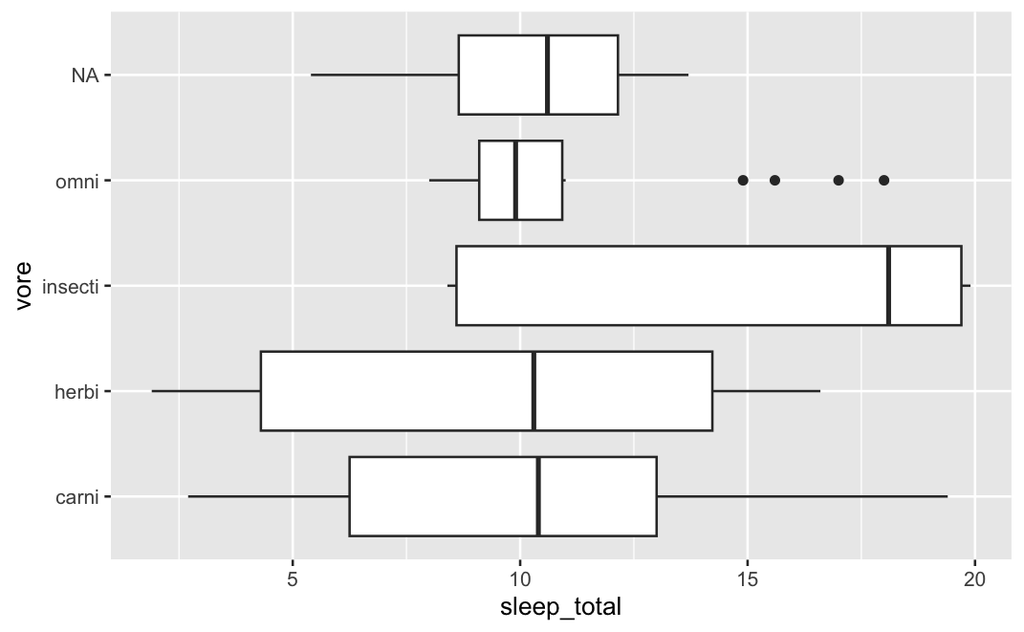

```r
sleep_data %>%
ggplot() +
  aes(x=sleep_total, y = vore) +
  geom_boxplot()
```

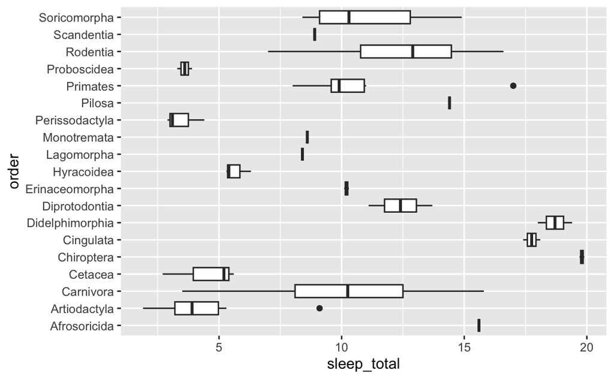

```r
sleep_data %>%
ggplot() +
  aes(x=sleep_total, y = order) +
  geom_boxplot()
```

#Q2 Jabberwockies

Observed statistics. Average sleep for jabberwockies is 7 hours/night

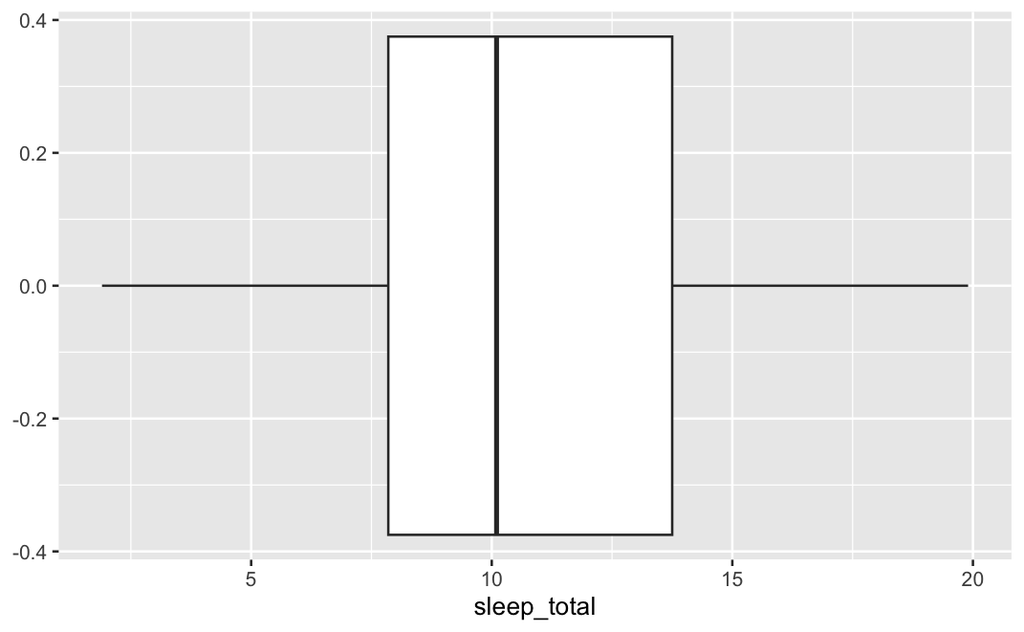

```r
sleep_data %>%
ggplot() +
  aes(x=sleep_total) +
  geom_boxplot()
```

```r
sleep_stats <- sleep_data %>%
  summarise(min = min(sleep_total),
            q1 = quantile(sleep_total,0.25),
            mean = mean(sleep_total),
            q3 = quantile(sleep_total,0.75),
            max = max(sleep_total))
```

sleep data shows that in the sampled animal population, sleep varies from 1.9 to 19.9 with a mean of 10.4. If we sampled this, how often would we get a mean value that is 7. My guess is not very often.

Null hypothesis is that the mean of the sample population is not different to 7.

H0 mean_sleep_total = 7 HA mean_sleep_total != 7

or

H0 mean_sleep_total - 7 = 0 HA mean_sleep_total - 7 != 0

Set alpha to be 0.05 for this test

example infer workflow: specify() #specify the the variables of interest hypothesize() # state the null hypothesis  
generate() # what method will use to generate null hypotheses  
calculate() #statistic of interest

```r
null_distribution <- sleep_data %>%
  specify(response = sleep_total) %>%  #we want to test this variable
  hypothesize(null = "point", mu = 7) %>%  #null hypothesis is that mean = 7
  generate(reps = 10000, type = "bootstrap") %>%  # what method will use to generate null hypotheses
  calculate(stat = "mean") #statistic of interest
```

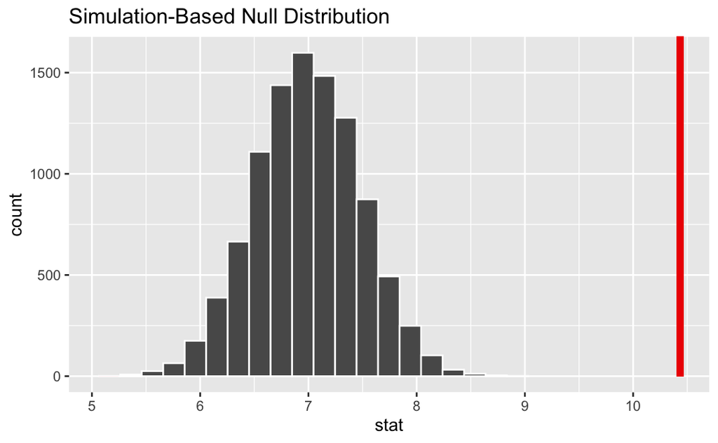

```r
null_distribution %>%
  visualise(bins = 20) +
  shade_p_value(obs_stat = sleep_stats$mean, direction = "both")
```

```r
p_value <- null_distribution %>%
 get_p_value(obs_stat = sleep_stats$mean, direction = "both")
 pull()
```

```
Error in UseMethod("pull") :
  no applicable method for 'pull' applied to an object of class "NULL"
```

```r
p_value
```

| p_value |
| --- |
| 0 |

The pvalue is very low (close to zero) this means that we can reject the null hypothesis. We can therefore have confidence that our alternative hypothesis is true. This alternative hypothesis was that the average sleep time for a jaberwocky, at 7 hours was significantly different to the mean of all the animal population.

# diversion !! check this method using the sample with replacement code.

[figure not shown]

OR

```r
  this_bootstrap <- sleep_data %>%
    specify(response = sleep_total) %>%
    generate(reps = 10000, type = "bootstrap") %>%
    calculate(stat = "mean") %>%
    mutate(stat = stat - (mean(stat) - 7))
```

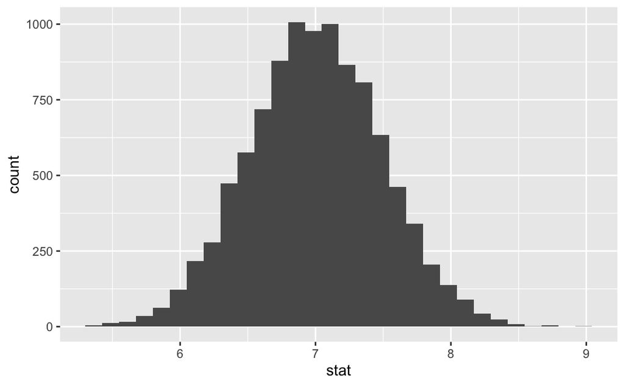

```r
this_bootstrap %>%
ggplot() +
  aes(x=stat) +
  geom_histogram()
```

#Q3 Omnivores v Herbivores - who is the sleepiest.

Omnivores and Herbivores are two different populations in the animals dataset. This is a two-sample test

Step 1.

Our null hypothesis is that the mean sleep time for omnivores is less than or equal to the mean sleep time for herbivores

The alternate hypothesis is that the mean sleep time for omnivores is greater than the mean sleep time for herbivores.

H0 avg_sleep_omni - avg_sleep_herbi <= 0 HA avg_sleep_omni - avg_sleep_herbi > 0

Set alpha to be 0.05 for this test

Now take a quick look at the data

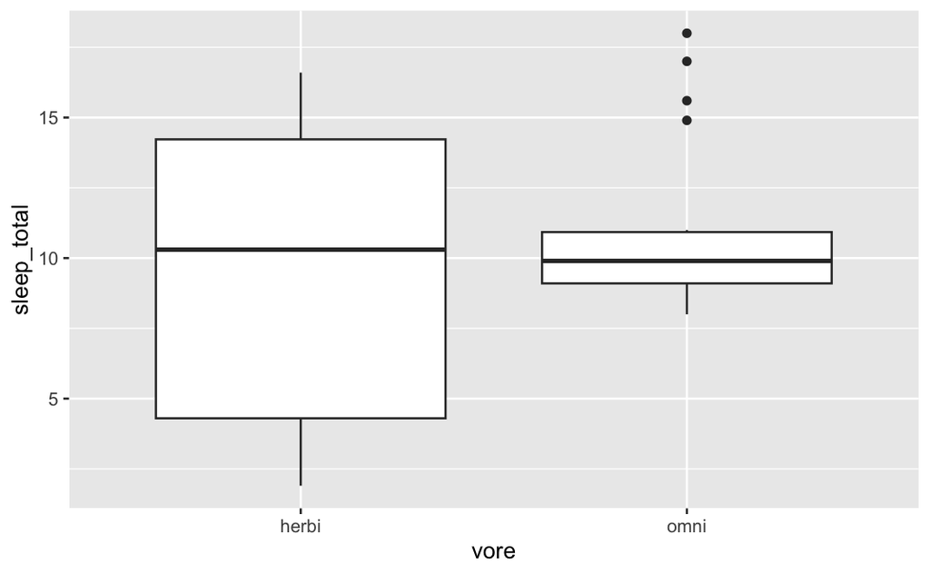

```r
sleep_data %>%
  filter(vore %in% c("herbi","omni")) %>%
  ggplot() +
  aes(y = sleep_total, x = vore) +
  geom_boxplot()
```

The boxplot suggests that omnivores do not sleep longer than herbivores? But note that the central line on the boxplot is the median value not the mean.

Step 2. Calculate observed stat

```r
vore_data <- sleep_data %>%
  filter(vore %in% c("herbi","omni"))

vore_stats <- sleep_data %>%
  filter(vore %in% c("herbi","omni")) %>%
  group_by(vore) %>%
  summarise(mean = mean(sleep_total))
vore_stats_diff=diff(vore_stats$mean)
```

The mean sleep_total for omnivore is 10.93 and mean for herbivores is 9.51 The difference is 1.41 hours

Step 3. Generate null distribution

```r
null_distribution <- vore_data %>%
  specify(response = sleep_total, explanatory = vore) %>%
  hypothesise(null = "independence") %>%  #H0 there is no dependance
  generate(reps = 10000, type = "permute") %>% #permute to shuffle labels
  calculate(stat = "diff in means",
            order = c("omni","herbi")) #omni - herbi
```

Step 4. Visualise the null distribution with observed statistic

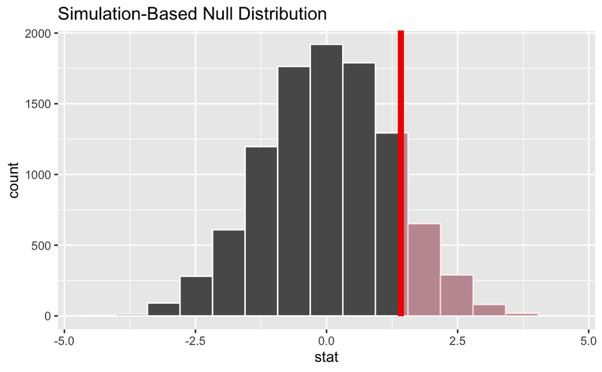

```r
null_distribution %>%
  visualise() +
  shade_p_value(obs_stat = vore_stats_diff,
                direction = "greater")
```

Step 5. extract p_value

```r
p_value <- null_distribution %>%
  get_p_value(obs_stat = vore_stats_diff,
              direction = "greater") %>%
  pull()
```

Step 6. conclusions

The p-value for this test is 0.12, this is greater than 0.05 and therefore we cannot reject the null hypothesis. We cannot say that omnivores sleep for longer (on average) than hermivores.